# Prediction understanding

Mateusz Staniak

## Why explain a single prediction?

(Bird’s-eye view)

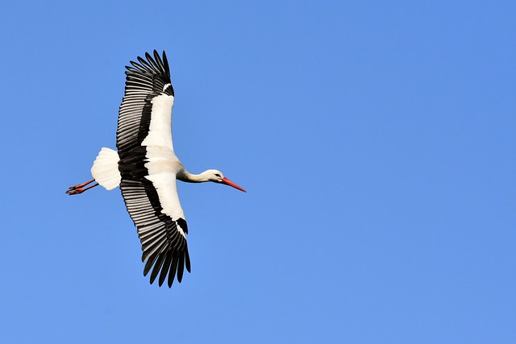

- when important decision are made based on ML model, it needs to be **trustworthy**
- trust comes from **understanding**
- the demand for interpretable algorithms is growing (see: *Weapons of math destruction*, Facebook feed controversies etc.)

(Worm-eye view)

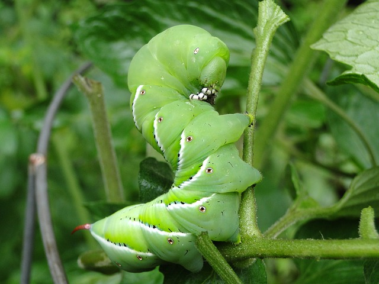

- this demand is transfered into legal regulations (see: RODO)

=> more and more institutions have to explain model predictions (debt collection, loans …)

- understanding models helps improve them

## Which predictions need explanation?

1. Every prediction the client (or the boss) wants to understand
2. Predictions that seem suspicious
   - How to spot them?
   - How to explain them?

**=> model performance**

**=> model diagnostics**

## Model diagnostics: example data

```r
library(tidyverse)
library(readr)
library(randomForest)
house <- read_csv("mieszkania.csv")
house <- mutate_if(house, is.character, as.factor)
house # pozmieniam nazwy na angielskie
```

```
## # A tibble: 5,851 x 7
##    n_pokoj metraz cena_m2   rok pietro pietro_maks dzielnica
##      <int>  <dbl>   <int> <int>  <int>       <int> <fct>
##  1       3   89.0    5270  2007      2           2 Krzyki
##  2       4  163.     6687  2002      2           2 Psie Pole
##  3       3   52.0    6731  1930      1           2 Srodmiescie
##  4       4   95.0    5525  2016      1           2 Krzyki
##  5       4   88.0    5216  1930      3           4 Srodmiescie
##  6       2   50.0    5600  1915      3           4 Krzyki
##  7       2   48.0    9146  2010      2           6 Fabryczna
##  8       2   46.0    9761  2011      4           6 Stare Miasto
##  9       3   67.0    5209  1990      1          10 Fabryczna
## 10       2   45.8    6878  2000      3           4 Krzyki
## # ... with 5,841 more rows
```

```r
load("rda_files/house_rf.rda")
house_task <- mlr::makeRegrTask(id = "mieszkania", data = house, target = "cena_m2")
hrf <- mlr::getLearnerModel(house_rf)
```

## Model diagnostics: predicted vs observed values

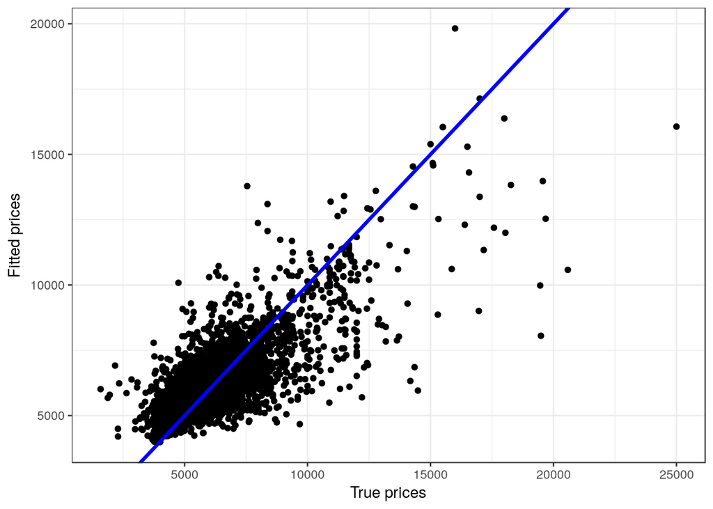

- Points on the plot should be close to the `y = x` line,
- Questions:
  - is there a pattern? (For example: does the devation from true value grow as true value grows?)
  - are there any points especially far from the line (meaning: points with large residuals)?

## Model performance

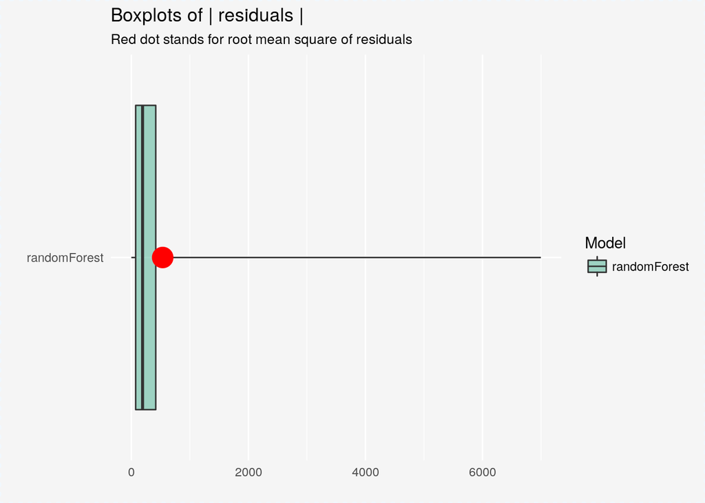

```r
library(DALEX)
rf_explainer <- explain(hrf, data = house, y = house$cena_m2)
rf_perf <- model_performance(rf_explainer)
plot(rf_perf, geom = "boxplot")
```

- shortly summarizes the distribution of the absolute value of residuals
- red dot is the root mean square error
- we can put boxplots for several models on the same plot (simply by passing the as arguments to `plot`) to compare models
- boxplots help discover outliers

## Single prediction explanation

- Once we identified predictions we want to explain, we need tools that will help us!
- Methods:
  - LIME
  - Shapley values
  - Break Down
  - LIVE
- Two main ideas:
  - Attribute scores to explanatory variables according to their influence on the prediction (**contributions**)
  - Fit a model locally around an observation and investigate it
  - NOTE: both approaches lead to local feature importance
- Contributions: Shapley values and Break Down
- Local models: LIME and LIVE

## LIME (Locally Interpretable Model-agnostic Explanations)

- General idea

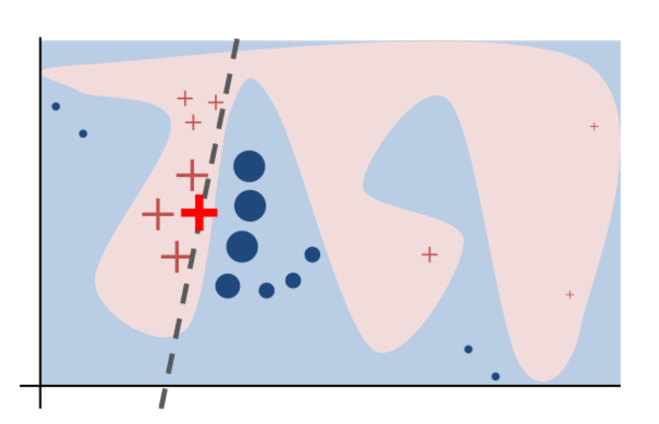

- Some details:
  - Gaussian sampling for tabular, uniform sampling from interpretable inputs for image/text.
- Scores for new observation are weighted by the distance from original observation.
- Variable selection is usually based on ridge/lasso regression.
- Weights are assigned to interpretable inputs to decide if they *vote* for or against a given label.
- Note: method depends on many hyperparameters

### Example

```r
library(lime)
explained_prediction <- house[4036, ]
lime_explainer <- lime(house,
                       model = hrf)
model_type.randomForest <- function(x, ...) "regression"
# predict_model.randomForest <- function(x, newdata, type, ...) {
#   predict(x, newdata, type = "response")
# }
# lime_explanation <- lime::explain(house[4036, ],
#                                   explainer = lime_explainer,
#                                   n_features = 10,
                                  # feature_select = "none")
```

## Shapley values

- General idea
  - The goal is a decomposition of prediction into a **sum** of scores related to (simplified) features.
  - The problem is solved using game theory: *Shapley values*. Variables are *players* who contribute to the outcome - the prediction - and we try to *pay* them accordingly to their contributions.
- This approach unifies several methods (including `LIME`).
- Some details
  - Exact methods exist for linear models and tree ensemble methods. In other cases, approximations are needed.
  - The classic way: sample permutations of variables, then average contributions.
  - The better way: approximation based on LIME and Shapley values for regression.
- This method has good theoretical properties, but will not produce sparse explanations

### Example

```r
library(shapleyr)
shapley_explanation <- shapley(4036,
                               task = house_task,
                               model = house_rf)
class(shapley_explanation) <- c("shapley.singleValue", "list")
gather(shapley_explanation$values, "feature", "shapley.score")
```

```
##       feature shapley.score
## 1         _Id          4036
## 2      _Class          <NA>
## 3     n_pokoj      -180.474
## 4      metraz      -224.901
## 5         rok        213.33
## 6      pietro      -128.518
## 7 pietro_maks         0.055
## 8   dzielnica      -567.581
```

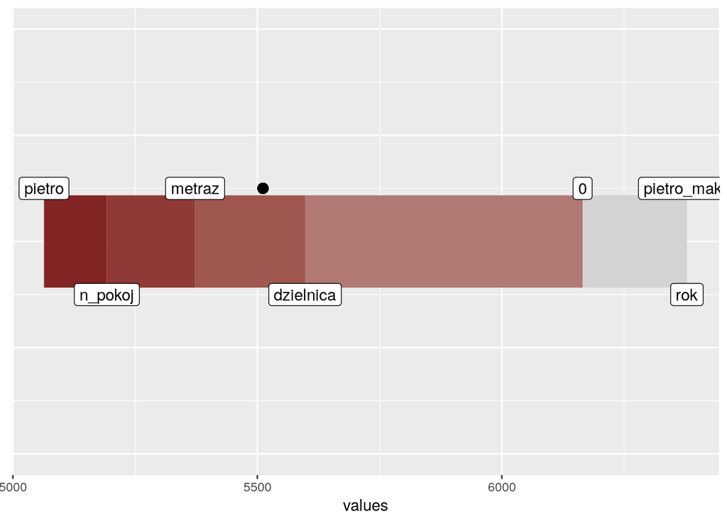

```r
plot(shapley_explanation)
```

- **0** is the mean of all predictions
- the **black dot** is the prediction we are explaining
- values and the plot describe how we move from the global mean of predictions to this particular predictions
- most important features are the ones that help move the most

## But isn’t it enough to calculate feature importance?

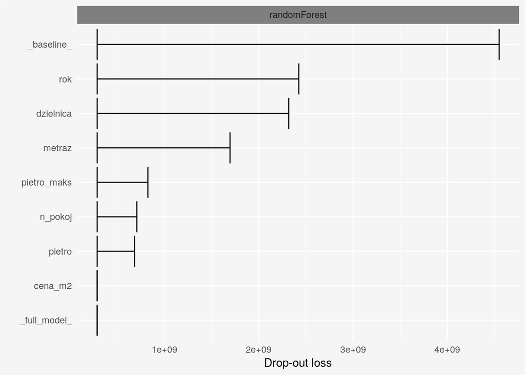

```r
global_feat_imp <- DALEX::variable_importance(rf_explainer)
plot(global_feat_imp)
```

- No. Particular instances can be influenced the most by different features, not necessarily the ones that are most important globally.

## Break Down

- General idea

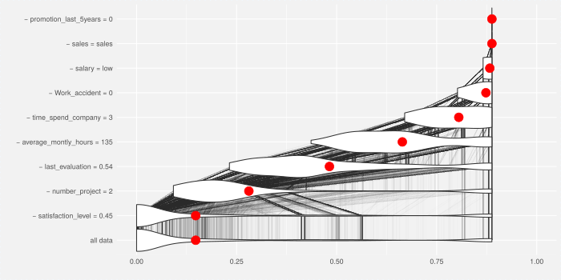

- Another approach to finding *additive* feature contributions
- Contributions are assigned in a greedy manner
- Waterfall plots as a visual tool

**=> more intuitive interpretation**

### Example

- Break Down for linear models

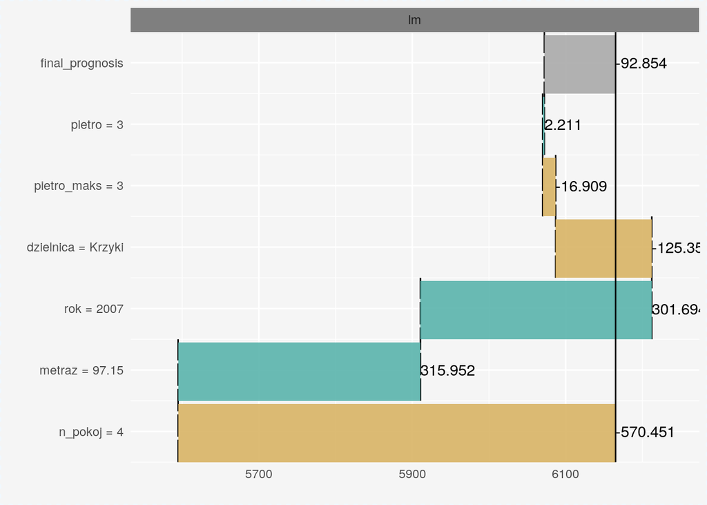

[output not shown]

```r
linear_model <- lm(cena_m2 ~., data = house)
lm_explainer <- DALEX::explain(linear_model, data = house, y = house$cena_m2)
breakdown_linear <- single_prediction(lm_explainer, house[4036, -3])
plot(breakdown_linear)
```

- Model-agnostic Break Down

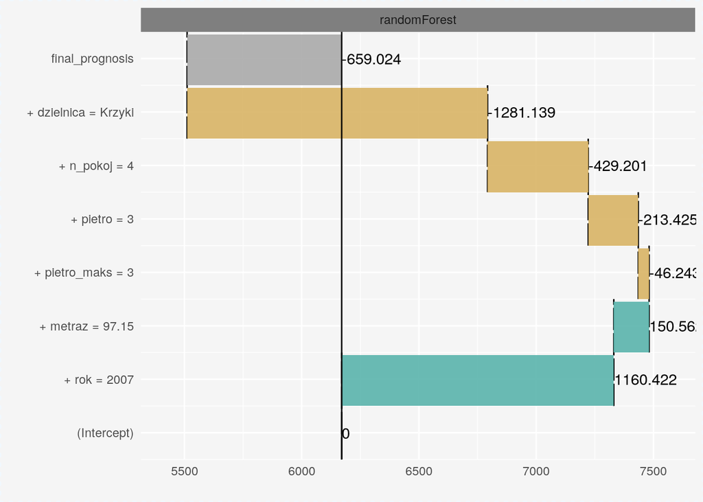

```r
breakdown_explanation <- single_prediction(rf_explainer, house[4036, -3])
plot(breakdown_explanation)
```

- Again, we can see how important District and Year are in this random forest prediction

## LIVE (Local Interpretable Visual Explanations)

- General idea
  - Modification of `LIME` for tabular data and regression problems with emphasis on model visualization.
  - Similar observations for *fake* dataset are sampled from empirical distributions.
  - Variable selection is possible (LASSO, then explanation model is fitted to selected features).
- More details
  - Two methods of creating the new dataset are available: by permuting each variable and by changing one feature per observations
  - We can control which variables are allowed to vary through `fixed` variable argument to `sample_locally` (keeping date/factor/correlated variables unchanged)

### Example

```r
library(live)
new_dataset <- sample_locally(data = house,
                              explained_instance = house[4036, ],
                              explained_var = "cena_m2",
                              size = 1000)
with_predictions <- add_predictions(new_dataset, hrf)
live_explanation <- fit_explanation(with_predictions, "regr.lm")
```

Aktualnie standaryzacja zmiennych jest niepotrzebnie w sample_locally, jak to zmienię, forestplot będzie lepiej wyglądał, bo będzie po standaryzacji

- Default method of sampling is *live*, default explanation model is linear regression and distance is measured (weights are assigned) by gaussian kernel.
- Plot local model structure: forest plot

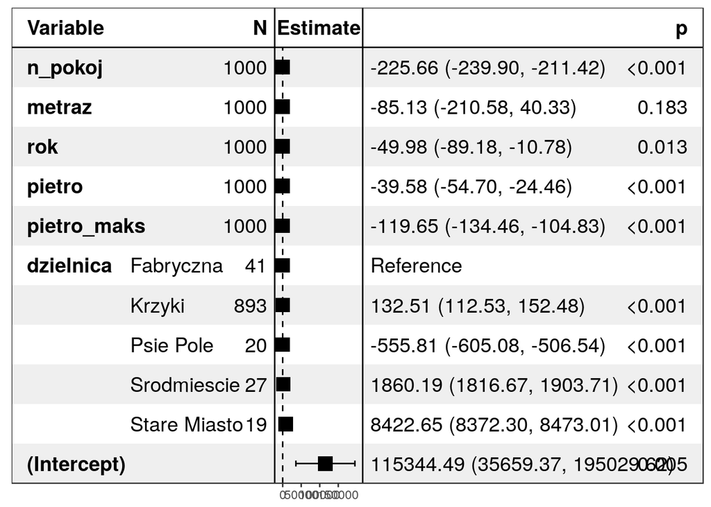

```r
plot_explanation(live_explanation, "forest")
```

- Plot local variable contributions: waterfall plot (Break Down)

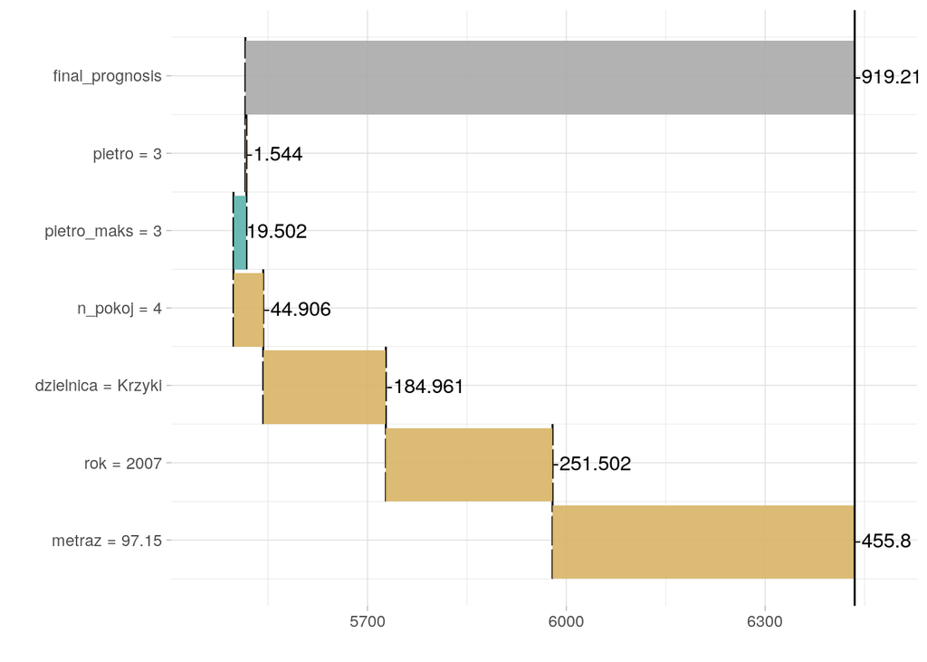

```r
plot_explanation(live_explanation, "waterfall")
```